# How many mutations are enough to rule linkage out?

Author

Hunter Ries

## Introduction

When two pathogen genomes are separated by *k* mutations, how confident can we be that the cases are *directly linked* by transmission? This document explores that question by simulating pairs of linked and un-linked cases and computing the empirical probability P(directly linked | *k* mutations) for each observed mutation count.

The key insight is asymmetric: a *small* number of mutations cannot confirm linkage (many un-linked pairs also differ by few mutations when evolutionary rates are low), but a *large* number of mutations can effectively rule linkage out. This is because directly linked pairs are constrained by the serial interval, while un-linked pairs accumulate mutations over much longer divergence times.

This document recapitulates Figures 3.5 and 3.6 from Alli Black’s [*Applied Genomic Epidemiology Handbook* §3.7.1](https://alliblk.github.io/genepi-book/fundamental-theory-in-genomic-epidemiology.html#how-many-mutations-are-enough-to-rule-linkage-out), generalized so that pathogen parameters can be swapped easily via a single editable table.

## Setup

```r
library(tidyverse)
set.seed(920674206)
```

## Pathogen parameters

Edit this table to add or modify pathogens. Each row drives one simulation and plot.

```r
pathogens <- tibble(
  name              = c("pandemic H1N1",
                        "SARS-CoV-2",
                        "West Nile virus",
                        "Mpox clade IIb",
                        "HIV-1 (pol region)",
                        "Influenza A H3N2"),
  mu_subs_site_year = c(0.003406, 0.0008, 0.0005, 0.00006, 0.0025, 0.0045),
  genome_length_nt  = c(13154,    29903,  11000,  197000,   9200,   13500),
  si_mean_days      = c(3.0,      5.0,    14.0,   9.0,      60.0,   3.0),
  si_sd_days        = c(1.0,      1.5,    4.0,    3.0,      30.0,   1.0)
)
# NOTE: West Nile virus is vector-borne — "serial interval" is a loose
# approximation (vector–host cycle time varies widely). Interpret WNV plots
# with caution.
#
# NOTE: HIV-1 is a chronic infection with highly variable time to onward
# transmission. The "serial interval" here is a rough placeholder; the
# resulting plots should be treated as illustrative only.
```

## Simulation function

```r
#' Simulate linked and unlinked genome pairs and compute P(linked | k)
#'
#' @param mu Substitution rate (subs/site/year)
#' @param L Genome length (nt)
#' @param si_mean Mean serial interval (days)
#' @param si_sd SD of serial interval (days)
#' @param n_pairs Number of pairs to simulate per class per replicate
#' @param n_reps Number of independent replicates (each yields its own
#'   P(linked|k) estimate, creating vertical spread in the plot)
#' @param unlinked_multiplier_range Range of multipliers on si_mean for
#'   unlinked divergence times
#' @return A tibble with columns rep, k, prob_linked_given_k
simulate_linkage <- function(mu, L, si_mean, si_sd,
                             n_pairs = 1000,
                             n_reps = 200,
                             unlinked_multiplier_range = c(5, 50)) {

  # Gamma parameters for the serial interval (in days)
  shape <- (si_mean / si_sd)^2
  rate  <- si_mean / si_sd^2

  map_dfr(seq_len(n_reps), function(r) {

    # --- Linked pairs ---
    tau_linked    <- rgamma(n_pairs, shape = shape, rate = rate)
    lambda_linked <- mu * L * (tau_linked / 365.25)
    k_linked      <- rpois(n_pairs, lambda = lambda_linked)

    # --- Unlinked pairs ---
    tau_unlinked    <- runif(
      n_pairs,
      min = unlinked_multiplier_range[1] * si_mean,
      max = unlinked_multiplier_range[2] * si_mean
    )
    lambda_unlinked <- mu * L * (tau_unlinked / 365.25)
    k_unlinked      <- rpois(n_pairs, lambda = lambda_unlinked)

    # --- P(linked | k) for this replicate ---
    n_linked_k   <- table(factor(k_linked))
    n_unlinked_k <- table(factor(k_unlinked))
    all_k        <- union(names(n_linked_k), names(n_unlinked_k))

    tibble(
      k = as.integer(all_k),
      n_linked   = as.integer(n_linked_k[all_k]),
      n_unlinked = as.integer(n_unlinked_k[all_k])
    ) |>
      replace_na(list(n_linked = 0L, n_unlinked = 0L)) |>
      mutate(
        prob_linked_given_k = n_linked / (n_linked + n_unlinked),
        rep = r
      ) |>
      select(rep, k, prob_linked_given_k)
  })
}
```

## Plotting function

```r
#' Plot P(directly linked | k mutations) for linked-pair samples
#'
#' @param sim_df Output of simulate_linkage()
#' @param title Plot title
#' @param subtitle Plot subtitle
#' @param k_min_display Minimum k value shown on x-axis (default 5)
#' @return A ggplot object
plot_linkage <- function(sim_df, title, subtitle, k_min_display = 5) {

  # Show at least k_min_display on x-axis
  n_reps  <- n_distinct(sim_df$rep)
  k_rep_counts <- sim_df |> count(k) # number of reps that produced this k
  k_max_data   <- max(
    k_rep_counts$k[k_rep_counts$n >= 0.25 * n_reps],
    na.rm = TRUE
  )
  # Override k_max_data
  k_max_data <- k_min_display
  k_max <- max(k_min_display, k_max_data)

  plot_df <- sim_df |> filter(k <= k_max)

  ggplot(plot_df, aes(x = k, y = prob_linked_given_k)) +
    geom_violin(
      aes(group = k),
      fill = "grey80", colour = NA, alpha = 0.5,
      scale = "width", width = 0.7
    ) +
    geom_jitter(
      width = 0.2, height = 0,
      alpha = 0.15, size = 0.5, colour = "steelblue"
    ) +
    geom_hline(yintercept = 0.05, linetype = "dashed", colour = "grey40") +
    annotate(
      "text", x = k_max * 0.85, y = 0.08,
      label = "5% rule-out threshold",
      size = 3, colour = "grey40"
    ) +
    scale_x_continuous(breaks = seq(0, k_max, by = 1)) +
    scale_y_continuous(limits = c(0, 1), labels = scales::percent) +
    labs(
      x        = "Mutations separating consensus genomes",
      y        = "P(directly linked)",
      title    = title,
      subtitle = subtitle
    ) +
    theme_minimal(base_size = 12) +
    theme(panel.grid.minor = element_blank())
}
```

## Results

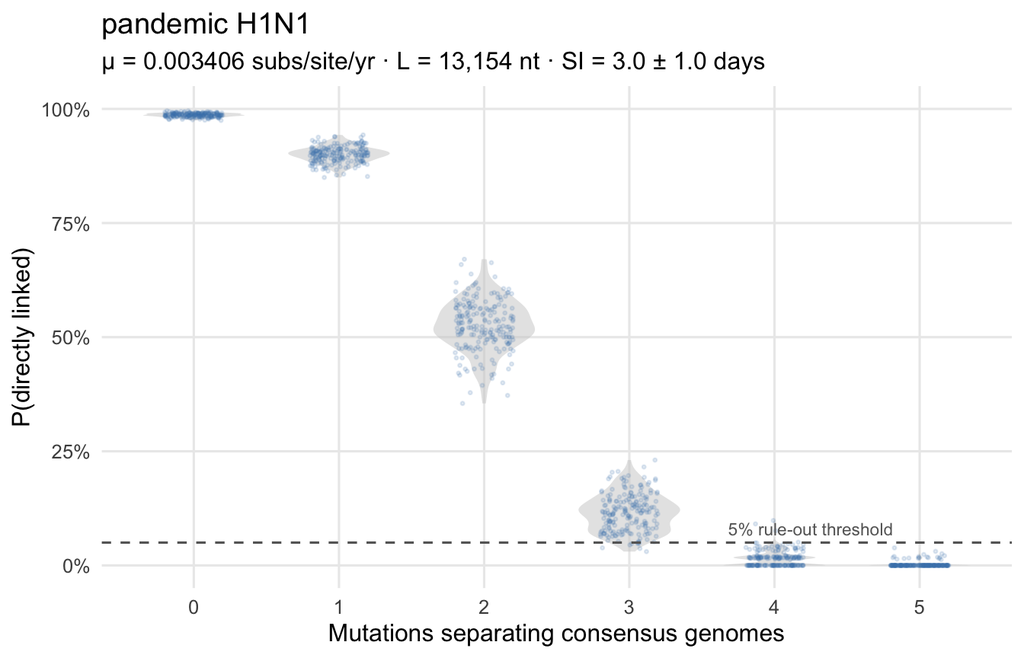

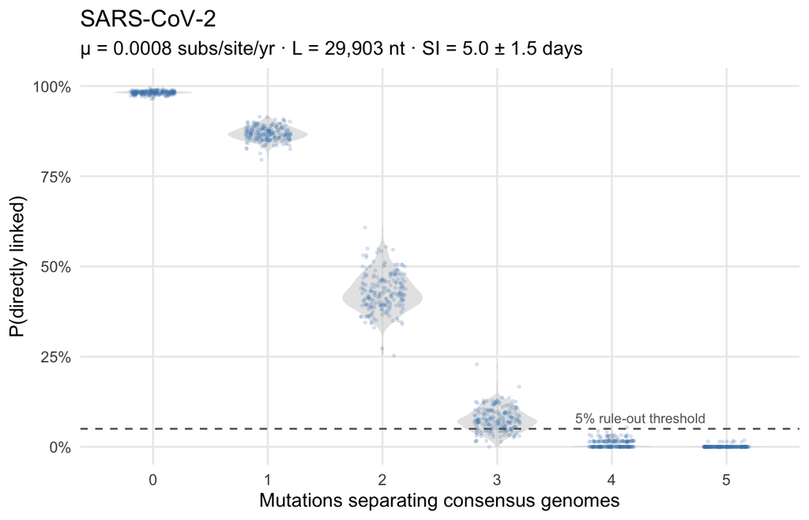

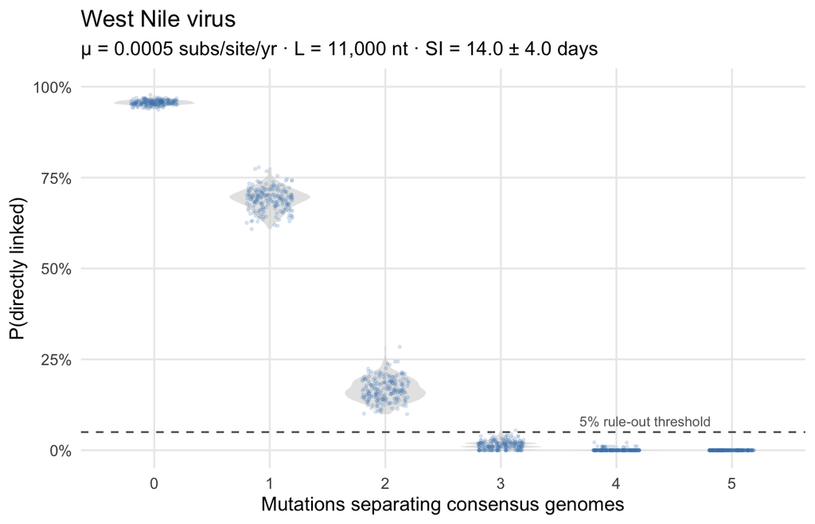

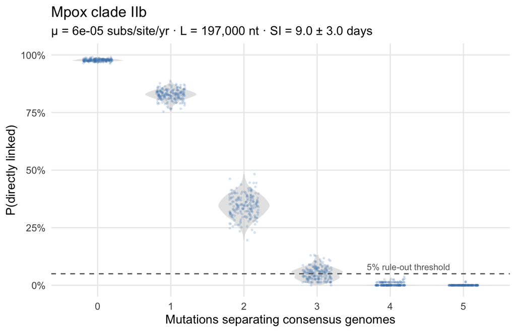

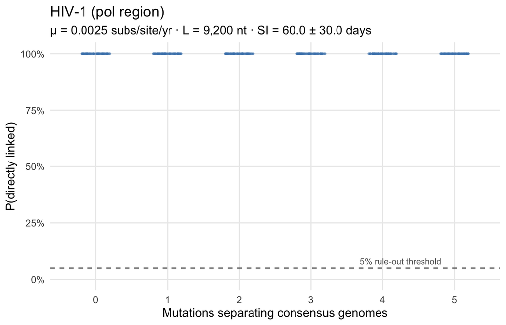

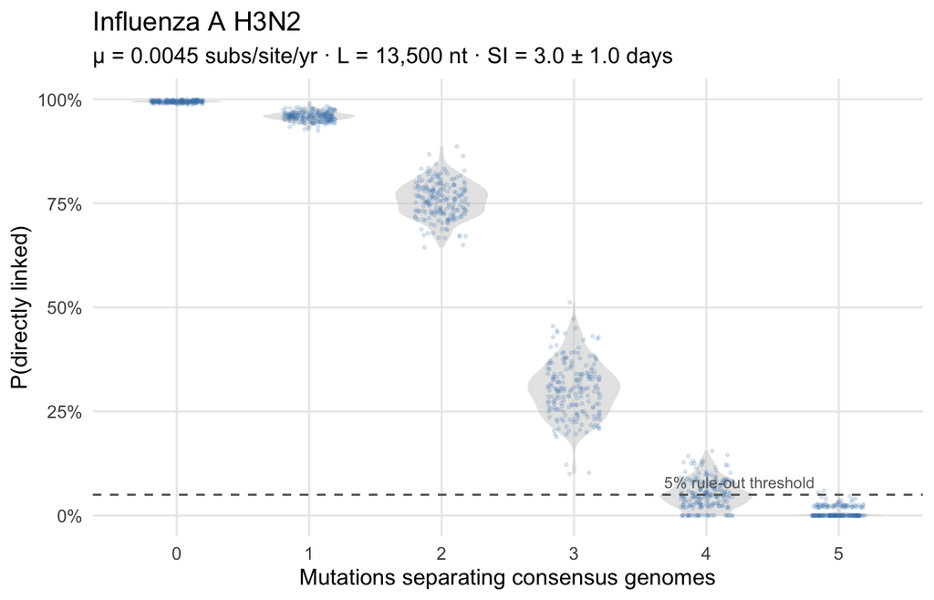

```r
pwalk(pathogens, function(name, mu_subs_site_year, genome_length_nt,
                          si_mean_days, si_sd_days) {
  sim <- simulate_linkage(
    mu      = mu_subs_site_year,
    L       = genome_length_nt,
    si_mean = si_mean_days,
    si_sd   = si_sd_days
  )

  subtitle <- sprintf(
    "\u03bc = %g subs/site/yr \u00b7 L = %s nt \u00b7 SI = %.1f \u00b1 %.1f days",
    mu_subs_site_year,
    format(genome_length_nt, big.mark = ","),
    si_mean_days,
    si_sd_days
  )

  p <- plot_linkage(sim, title = name, subtitle = subtitle)
  print(p)
})
```

## Modeling caveats

- The **50/50 prior on linkage** is implicit in pooling equal numbers of linked and un-linked simulated pairs. Real outbreak datasets have different mixing ratios, and the posterior probability shifts accordingly.
- **Within-host diversity**, **transmission bottlenecks**, and the fact that mutations accumulate on *both* sides of the MRCA are all collapsed into a single Poisson draw per pair.
- **Serial interval ≠ generation interval**; we are conflating them here for simplicity.
- For **vector-borne** pathogens (West Nile virus) and **chronic** infections (HIV), the “serial interval” framing breaks down. Treat those plots as illustrative only.
- A future version should add an **analytic Bayesian solution** (gamma–Poisson conjugacy → negative binomial marginal) with an explicit, tunable prior on linkage.